# Project 3 Logistic Regression

## Below we look at the optimal value of lambda and explore the model

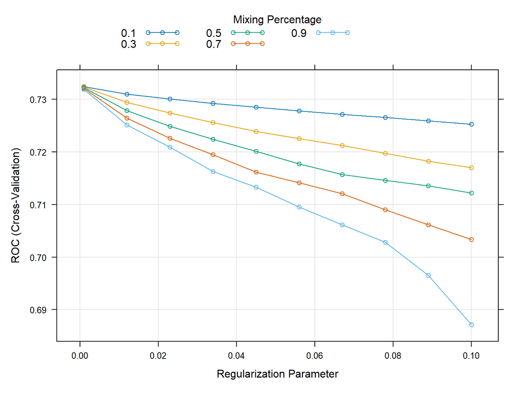

```r
plot(logit_fit)
```

```r
logit_fit$bestTune
```

```
##   alpha lambda
## 1   0.1  0.001
```

# Analysis

The above results shows that, the best tune for alpha= 0.1 and lambda= 0.001.

```r
logit_fit$results
```

```
##    alpha lambda       ROC      Sens      Spec       ROCSD      SensSD
## 1    0.1  0.001 0.7324088 0.6641150 0.6704835 0.006299557 0.004175224
## 2    0.1  0.012 0.7309938 0.6584326 0.6742360 0.006437941 0.004094278
## 3    0.1  0.023 0.7300950 0.6561597 0.6757798 0.006537793 0.004346895
## 4    0.1  0.034 0.7292370 0.6538438 0.6773453 0.006603334 0.003613705
## 5    0.1  0.045 0.7284933 0.6513779 0.6780743 0.006631291 0.003828911
## 6    0.1  0.056 0.7277780 0.6496624 0.6791036 0.006655585 0.004086000
## 7    0.1  0.067 0.7271602 0.6475824 0.6798112 0.006673221 0.004649827
## 8    0.1  0.078 0.7265478 0.6461029 0.6803902 0.006683655 0.004728490
## 9    0.1  0.089 0.7259256 0.6443231 0.6815482 0.006691734 0.005471233
## 10   0.1  0.100 0.7252792 0.6429722 0.6819341 0.006688782 0.005572470
## 11   0.3  0.001 0.7323266 0.6638792 0.6709552 0.006309063 0.004091800
## 12   0.3  0.012 0.7294011 0.6533077 0.6768949 0.006650642 0.003468541
## 13   0.3  0.023 0.7274226 0.6442158 0.6819985 0.006805833 0.004272150
## 14   0.3  0.034 0.7255562 0.6363248 0.6857081 0.006876686 0.005917627
```

[output cut: 87 more lines]

Analysis:

The component logit_fit$results gives us a data frame of performance metrics for each combination of tuning parameters. In this case, lambda was selected using the AUC value because we set the metric to ROC. The best lambda value was 0.001.

# coefficients of the model

```r
coef(logit_fit$finalModel,logit_fit$bestTune$lambda)
```

```
## 36 x 1 sparse Matrix of class "dgCMatrix"
##                                           s=0.001
## (Intercept)                         -2.875040e+00
## loan_amnt                           -1.406022e-05
## int_rate                            -1.851849e-02
## annual_inc                           1.941947e-06
## dti                                 -2.758065e-02
## open_acc                            -1.767162e-02
## pub_rec                             -7.462619e-02
## revol_bal                            3.526735e-06
## revol_util                          -8.008537e-04
## total_acc                            1.084823e-02
## mort_acc                             3.212726e-02
## pub_rec_bankruptcies                 1.107369e-01
## fico_range_low                       3.379583e-03
## fico_range_high                      3.393562e-03
## inq_last_6mths                      -7.646257e-02
## term__60_months                     -5.388396e-01
## home_ownership_OWN                  -1.378301e-01
## home_ownership_RENT                 -2.358199e-01
## verification_status_Source_Verified -1.414719e-01
## verification_status_Verified        -2.318631e-02
## grade_B                             -3.139997e-01
## grade_C                             -6.450249e-01
## grade_D                             -8.579993e-01
## grade_E                             -9.370010e-01
## grade_F                             -1.016975e+00
## grade_G                             -1.114353e+00
## purpose_debt_consolidation          -9.538666e-02
## purpose_home_improvement            -1.969358e-01
## purpose_other                       -1.917315e-01
## initial_list_status_w                2.036225e-02
## debt_settlement_flag_Y              -5.346633e+00
## emp_length_4_6_years                 2.310729e-02
## emp_length_7_9_years                -1.020618e-02
## emp_length_10plus_years              4.522072e-02
## emp_length_Unknown                  -5.285669e-01
## interaction_dti_interest             3.483389e-05
```

# Predict on the Test Set

Below we will create a dataframe that includes the predictions on the test data along with the actual values.

```r
pred.test <- holdout %>% dplyr::select(loan_default)
pred.test$netprob <- predict(logit_fit,
                           newdata = holdout,
                           type = "prob")[,"Yes"]

pred.test$netclass<- predict(logit_fit,
                                 newdata = holdout,
                                 type="raw")
```

# Evaluating the performance with confusion matrix

```r
table(pred.test$loan_default)
```

```
##
##    No   Yes
## 63698 15544
```

```r
table(pred.test$netclass)
```

```
##
##   Yes    No
## 31235 48007
```

```r
confusionMatrix(pred.test$netclass, pred.test$loan_default,positive="Yes")
```

```
## Confusion Matrix and Statistics
##
##           Reference
## Prediction    No   Yes
##        No  42697  5310
##        Yes 21001 10234
##
##                Accuracy : 0.668
##                  95% CI : (0.6647, 0.6712)
##     No Information Rate : 0.8038
##     P-Value [Acc > NIR] : 1
##
##                   Kappa : 0.2379
##
##  Mcnemar's Test P-Value : <2e-16
##
##             Sensitivity : 0.6584
##             Specificity : 0.6703
##          Pos Pred Value : 0.3276
##          Neg Pred Value : 0.8894
##              Prevalence : 0.1962
##          Detection Rate : 0.1291
##    Detection Prevalence : 0.3942
##       Balanced Accuracy : 0.6643
##
##        'Positive' Class : Yes
##
```

# Analysis:

The sensitivity level is 65% Specificity has 67% and Balanced Accuracy has 66%. the model stability is reasonably good in finding the true positives.

# ROC Curve

Now we access the Visualize trade-offs between sensitivity and specificity across all thresholds.

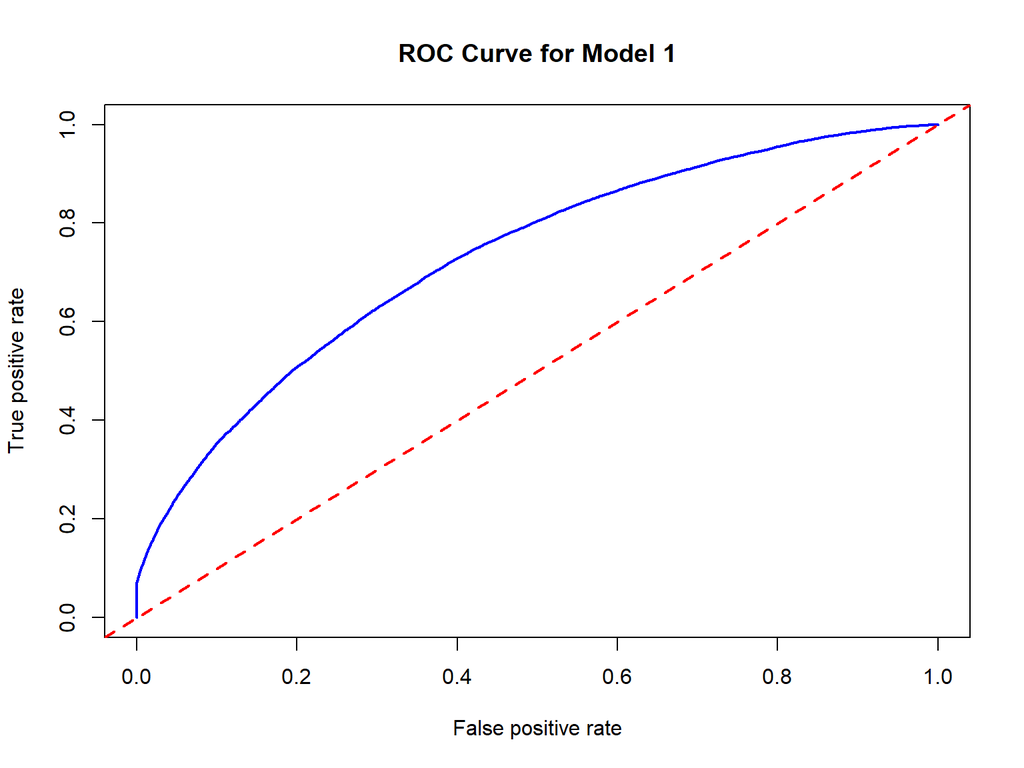

```r
pred <- prediction(pred.test$netprob, pred.test$loan_default)
perf <- performance(pred, "tpr", "fpr")
# Plot Curve
plot(perf, col = "blue", lwd = 2, main = "ROC Curve for Model 1")
abline(a = 0, b = 1, col = "red", lty = 2, lwd = 2)
```

```r
auc <- performance(pred, "auc")@y.values[[1]]
print(paste("The AUC is ",round(auc,2)))
```

```
## [1] "The AUC is  0.73"
```

## Step 1- Finding the Optimal Threshold using ROCR package

Generally we use the F1 Score to find the optimal threshold. Using the ROCR package, we can compute the precision and recall for each threshold We use this vector of values to compute the F1 Score for each threshold. The threshold that gives the highest F1 Score is the optimal threshold.

```r
pred <- ROCR::prediction(pred.test$netprob,holdout$loan_default)
prec <- ROCR::performance(pred, "prec")
rec <- ROCR::performance(pred, "rec")
precision <- prec@y.values[[1]]
recall <- rec@y.values[[1]]
f1=2*precision*recall/(precision+recall)
f1[is.nan(f1)]=0
cutoffs=prec@x.values[[1]]
df_f1=data.frame(f1,cutoffs)

opt_idx <- which.max(f1)
opt_f1 <- df_f1[opt_idx,]
opt_f1
```

```
##              f1  cutoffs
## 28322 0.4403511 0.521216
```